# Домашнее задание по базовой визуализации №2

Касьянова Мария

2024-10-08

## Загрузка данных

```r
hogwarts <- read_csv("../data/hogwarts_2024.csv")
hogwarts <- hogwarts |> mutate(
  across(c(house, course, sex, wandCore, bloodStatus), ~ as.factor(.x))
)
hogwarts |> head()
```

```
## # A tibble: 6 x 60
##      id house    course sex   wandCore bloodStatus result Defence against the ~1
##   <dbl> <fct>    <fct>  <fct> <fct>    <fct>        <dbl>                  <dbl>
## 1     1 Ravencl~ 4      fema~ unicorn~ half-blood      94                     73
## 2     2 Hufflep~ 5      male  phoenix~ half-blood      33                     38
## 3     3 Ravencl~ 4      fema~ dragon ~ half-blood     137                     52
## 4     4 Hufflep~ 2      male  phoenix~ half-blood      27                     50
## 5     5 Hufflep~ 2      fema~ phoenix~ half-blood      67                     47
## 6     6 Gryffin~ 6      male  phoenix~ muggle-born    126                     44
## # i abbreviated name: 1: `Defence against the dark arts exam`
## # i 52 more variables: `Flying exam` <dbl>, `Astronomy exam` <dbl>,
## #   `Herbology exam` <dbl>, `Divinations exam` <dbl>, `Charms exam` <dbl>,
## #   `History of magic exam` <dbl>, `Arithmancy exam` <dbl>,
## #   `Care of magical creatures exam` <dbl>, `Muggle studies exam` <dbl>,
## #   `Study of ancient runes exam` <dbl>, `Transfiguration exam` <dbl>,
## #   `Potions exam` <dbl>, week_1 <dbl>, week_2 <dbl>, week_3 <dbl>, ...
```

### Пересоздание theme_custom

```r
theme_custom <- theme(
    panel.background = element_rect(fill = "white"),
    plot.title = element_text(size = 30, hjust = 0.5),
    plot.subtitle = element_text(size = 25, hjust = 0.5),
    strip.text = element_text(size = 20),
    axis.text = element_text(size = 20),
    axis.title = element_text(size = 25),
    legend.title = element_text(size = 25),
    legend.text = element_text(size = 20)
  )
```

## Диаграммы рассеяния (скаттерплоты)

### 1. Успеваемость и травология

Построим скаттерплот, демонстрирующий взаимосвязь между общей оценкой ученика за год и оценкой за экзамен по травологии:

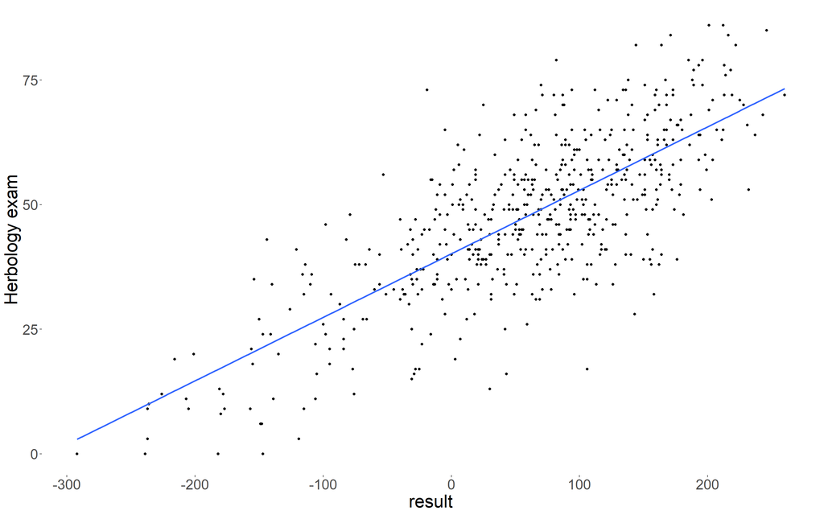

```r
hogwarts |>
  ggplot(aes(x = `result`,
                 y = `Herbology exam`))+
  geom_point()+
  theme_custom+
  geom_smooth(se = FALSE,
              method = "lm")
```

На графике можно увидеть неплохую скоррелированность суммарной оценки и оценки за травологию, причем ассоциация линейная. В целом это логичный результат, ведь скорее всего учащиеся, которые набрали высокий суммарный балл, на травологии учились так же прилежно, как и на других дисциплинах.

### 2. Успеваемость и не только травология

Повторим для еще 3 предметов

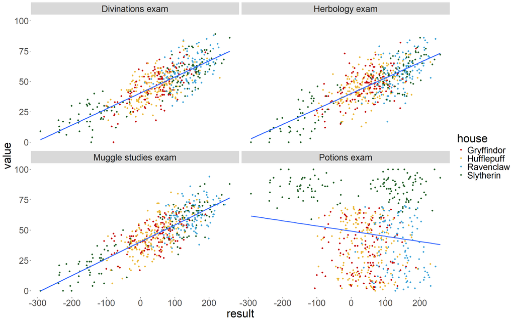

```r
hogwarts |>
  select(house, result, `Herbology exam`, `Divinations exam`, `Potions exam`, `Muggle studies exam`)|>
  pivot_longer(cols = c(`Herbology exam`, `Divinations exam`, `Potions exam`, `Muggle studies exam`),
               names_to = "Exam") |>
  ggplot(aes(x = `result`,
             y = `value`))+
  geom_point(aes(color = house))+
  theme_custom+
  facet_wrap(vars(Exam))+
  geom_smooth(se = FALSE,
              method = "lm")+
  scale_color_manual(values = c("Gryffindor" = "#C50000",
                             "Hufflepuff" = "#ECB939",
                             "Ravenclaw" = "#41A6D9",
                             "Slytherin" = "#1F5D25"))
```

Видно, что почти все экзамены подчиняются схожим зависимостям, кроме зельеварения. В данный момент линия тренда наклонная, что могло бы говорить о взаимосвязи, но это из-за специфичной структуры данных, которые разбиваются на две группы. Если бы мы отделили слизеринцкв от всех остальных, мы бы увидели, что оценки за зельеварение практически не связаны с годовой оценкой (просто у всех слизеринцев за зельеварение много, а у остальных мало, в то время как общая оценка за год по крайней мере у половины слизерина наименьшая в хогвартсе)

### 3. Успеваемость и слизерин

Собственно, выделим слизерин в отдельную группу и увидим то, что и предполагали. На экзамене по зельеваренью слизеринцам ставили наивысшие баллы независимо от их общей успеваемости, а на всех остальных факультетах балл ниже и тоже слабо коррелирует с общей оценкой. Логичное предположение, которое напрашивается при виде данной картины: оценки за зельеварение не отражают реальные знания, выставляются в зависимости от факультета (или обучение зельеварение принципиально отличается от обучения любой другой науке и требует совершенно других навыков, но это менее вероятная гипотеза):

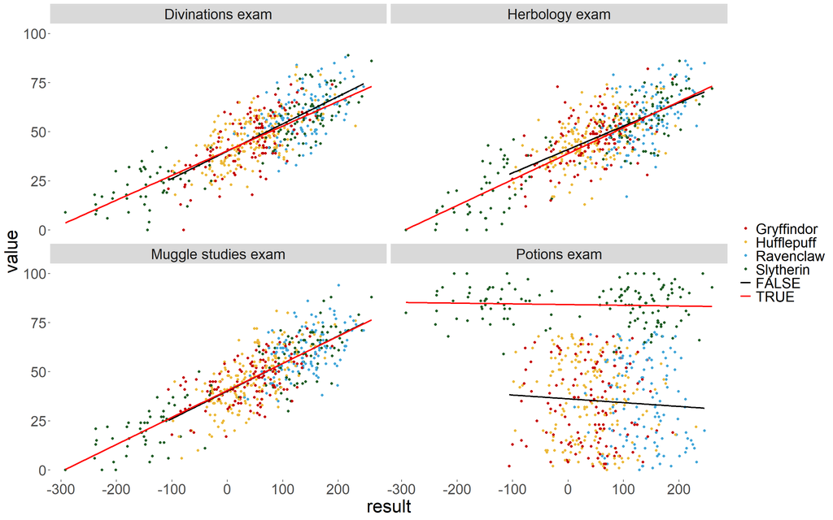

```r
hogwarts |>
  select(house, result, `Herbology exam`, `Divinations exam`, `Potions exam`, `Muggle studies exam`)|>
  pivot_longer(cols = c(`Herbology exam`, `Divinations exam`, `Potions exam`, `Muggle studies exam`),
               names_to = "Exam") |>
  ggplot(aes(x = `result`,
             y = `value`))+
  geom_point(aes(color = house))+
  theme_custom+
  facet_wrap(vars(Exam))+
  geom_smooth(se = FALSE,
              method = "lm",
              aes(color = (house == "Slytherin")))+
  scale_color_manual(values = c("Gryffindor" = "#C50000",
                             "Hufflepuff" = "#ECB939",
                             "Ravenclaw" = "#41A6D9",
                             "Slytherin" = "#1F5D25",
                             "TRUE" = "red",
                             "FALSE" = "black"))+
  labs(color = "")
```

## Geom_col

### 1. Первый семестр

Построим барплот, показывающий сумму баллов волшебников определенного происхождения

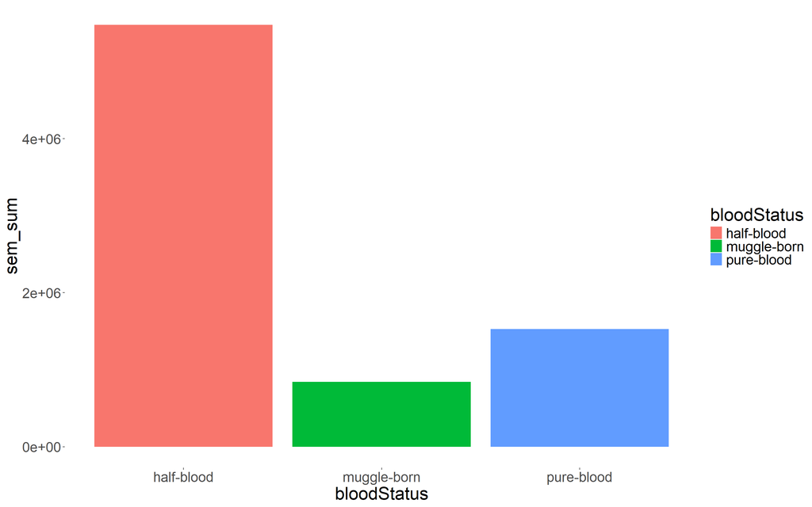

```r
hogwarts |>
  mutate(sem1 = sum(week_1, week_2, week_3, week_4, week_5, week_6, week_7, week_8, week_9, week_10, week_11, week_12, week_13, week_14, week_15, week_16, week_17))|>
  group_by(bloodStatus) |>
  summarise(sem_sum= sum(sem1))|>
  ggplot()+
  geom_col(aes(y=sem_sum, x= bloodStatus, fill = bloodStatus))+
  theme_custom
```

Мы видим, что суммарный балл, набранный волшебниками смешанного происхождения намного больше, чем у двух других групп. Поскольку в качестве функции использовалась сумма, такое распределение могло бы сильно зависеть от количества людей в каждой группе (возникает гипотеза, что полукровок просто намного больше)

### 2. Проверка гипотезы

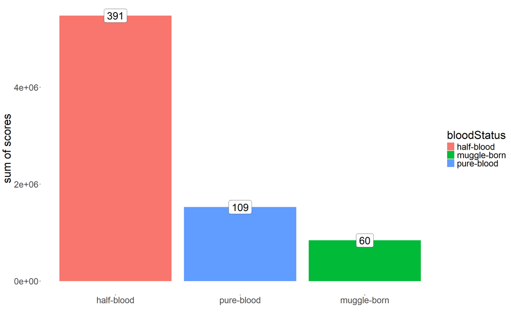

```r
hogwarts |>
  mutate(sem1 = sum(week_1, week_2, week_3, week_4, week_5, week_6, week_7, week_8, week_9, week_10, week_11, week_12, week_13, week_14, week_15, week_16, week_17))|>
  group_by(bloodStatus) |>
  summarise(sem_sum = sum(sem1),
            people_number = n())|>
  ggplot(aes(y = sem_sum,
             x= fct_reorder(bloodStatus, -sem_sum)))+
  geom_col(aes(fill = bloodStatus))+
  theme_custom+
  geom_label(aes(label = people_number),
            colour = "black",
            size = 8)+
  labs(x= "",
       y = "sum of scores")
```

И правда, добавив на график информацию о количестве студентов, можно легко понять, что чем больше в группе учеников, тем больше сумма набранных ими баллов.

### 3.

Добавим информацию про пол учащихся и сохраним график на устройство

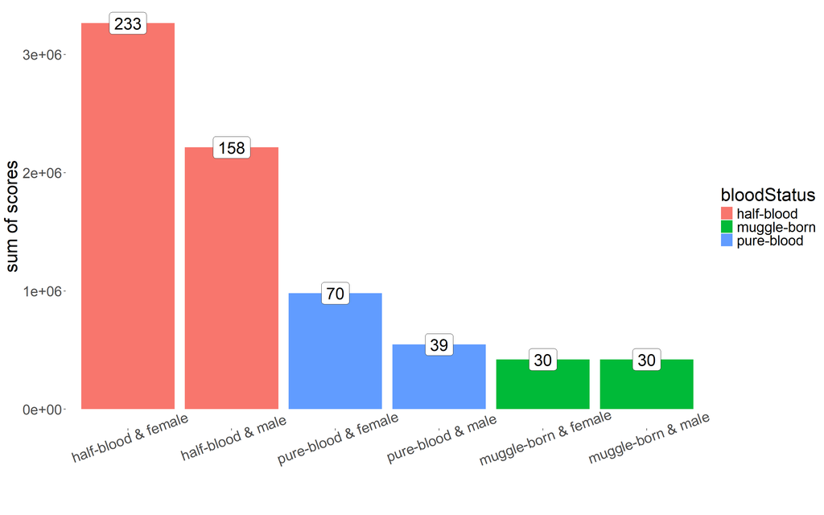

```r
plot1 <- hogwarts |>
  mutate(sem1 = sum(week_1, week_2, week_3, week_4, week_5, week_6, week_7, week_8, week_9, week_10, week_11, week_12, week_13, week_14, week_15, week_16, week_17))|>
  group_by(bloodStatus, sex) |>
  summarise(sem_sum = sum(sem1),
            people_number = n())|>
  mutate(`bloodStatus and sex` = paste0(bloodStatus, " & ", sex))|>
  ggplot(aes(y = sem_sum,
             x= fct_reorder(`bloodStatus and sex`, -sem_sum)))+
  geom_col(aes(fill = bloodStatus))+
  theme_custom+
  geom_label(aes(label = people_number),
            colour = "black",
            size = 8)+
  labs(x= "",
       y = "sum of scores")+
  theme(axis.text.x = element_text(angle = 20))

plot1
```

```r
ggsave("first_sem.png", plot1, width = 16, height = 10, dpi = 300)
```

### 4. Функция coord.flip()

Эта функция нужна для поворота графика (оси х и у меняются местами). Похожего эффекта можно добиться, если поменять местами значения, которые приравниваются переменным х и у внутри параметра aes(). Однако использование функции coord.flip() позволяет автоматически перенастроить параметры, относившиеся к осям х и у (например, пределы шкал заданные через xlim, направление заданное через scale_y_reverse и тд). Поэтому удобно применять эту функцию без переписывания остального кода.

## Разное

### 1. Зельеварение vs Руны

Сравним два экзамена. Для начала при помощи scatter plot:

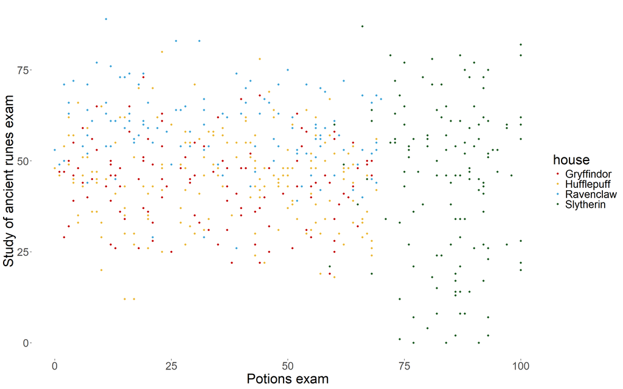

```r
plot1 <- hogwarts |>
  ggplot() +
  geom_point(aes(x = `Potions exam`,
                 y = `Study of ancient runes exam`,
                 color = house))+
  theme_custom+
  scale_color_manual(values = c("Gryffindor" = "#C50000",
                             "Hufflepuff" = "#ECB939",
                             "Ravenclaw" = "#41A6D9",
                             "Slytherin" = "#1F5D25"))
plot1
```

Мы видим, что ассоциации между двумя экзаменами не наблюдается, (зато по-прежднему видна связь между факультетом и оценой за зельеварение)

Теперь посмотрим на боксплоты, отражающие оценки за каждый из двух экзаменов в зависимости от факультета:

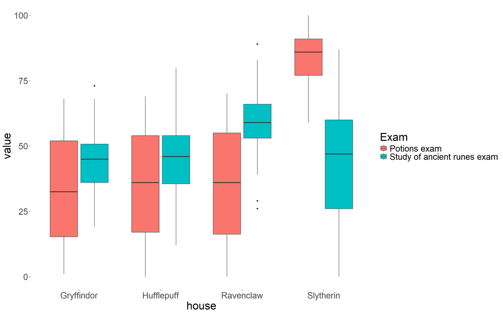

```r
plot2 <- hogwarts |>
  pivot_longer(cols = c(`Potions exam`, `Study of ancient runes exam`),
               names_to = "Exam")|>
  ggplot() +
  geom_boxplot(aes(x = house,
                 y = value,
                 fill = Exam))+
  theme_custom

plot2
```

Видно, что распределения оценок не совпадает ни на одном из факультетов.

Отобразим среднюю оценку за экзамены в зависимости от происхождения:

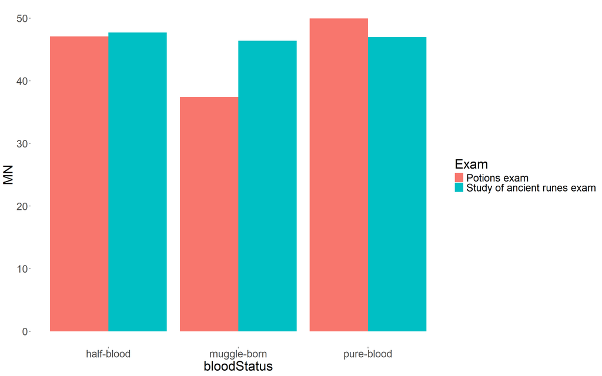

```r
plot3 <- hogwarts |>
  pivot_longer(cols = c(`Potions exam`, `Study of ancient runes exam`),
               names_to = "Exam")|>
  group_by(bloodStatus, Exam) |>
  summarise(MN= mean(value))|>
  ggplot(aes(y = MN,
             x= bloodStatus))+
  geom_col(aes(fill = Exam),
           position = "dodge")+
  theme_custom

plot3
```

Видно, что оценка за руны на зависит от происхождения, а на зельеварении все-таки различается между группами

Объединим графики:

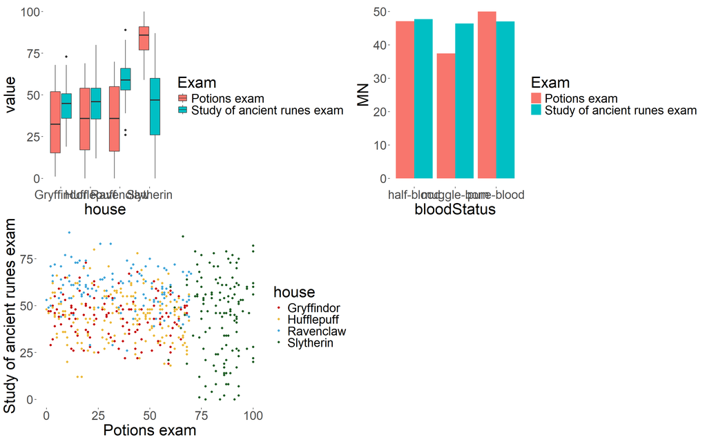

```r
ggarrange(plotlist = list(plot2,
                          plot3,
                          plot1),
          nrow = 2,
          ncol = 2)
```

### 2. Зельеварение и происхождение

Посмотрим, как зависит средний балл по зельеварению от происхождения ученика. Видно, что у маглорожденных он меньше. Поскольку мы помним, что балл по этому предмету очень сильно коррелирует с факультетом, появляется гипотеза, что среди маглорожденных меньше слизеринцев, из-за чего средний балл уменьшается. Проверим это на втором графике: доля слизеринце и правда меньше, если сравнивать с полукровками и чистокровными волшебниками

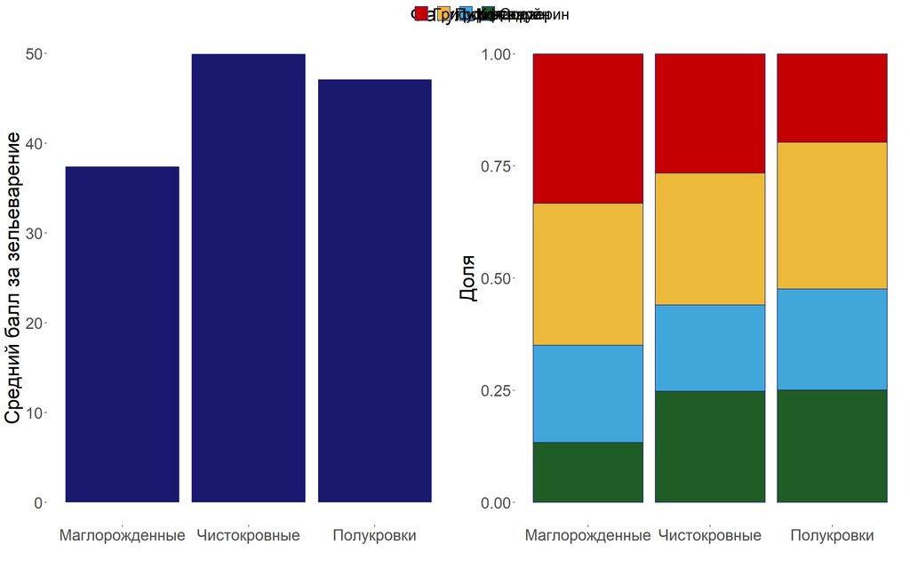

```r
hogwarts$bloodStatus <- factor(hogwarts$bloodStatus, levels = c("muggle-born", "pure-blood", "half-blood"))


plot1 <- hogwarts |>
  group_by(bloodStatus) |>
  summarise(MN= mean(`Potions exam`))|>
  ggplot(aes(y = MN,
             x= bloodStatus))+
  geom_col(fill = "midnightblue")+
  scale_x_discrete(labels = c("muggle-born" = "Маглорожденные",
                              "pure-blood" = "Чистокровные",
                              "half-blood" = "Полукровки"))+
  theme_custom+
  labs(x = "",
       y = "Средний балл за зельеварение")

plot2 <- ggplot(hogwarts)+
  geom_bar(aes(x = bloodStatus,
               fill = house),
           position = "fill",
           color = "midnightblue"
           )+
  theme_custom +
  scale_x_discrete(labels = c("muggle-born" = "Маглорожденные",
                              "pure-blood" = "Чистокровные",
                              "half-blood" = "Полукровки"))+
  scale_fill_manual(values = c("Gryffindor" = "#C50000",
                             "Hufflepuff" = "#ECB939",
                             "Ravenclaw" = "#41A6D9",
                             "Slytherin" = "#1F5D25"),
                    labels = c("Gryffindor" = "Гриффиндор",
                             "Hufflepuff" = "Пуффендуй",
                             "Ravenclaw" = "Когтевран",
                             "Slytherin" = "Слизерин"))+
  labs(x = "",
       y = "Доля",
       fill = "Факультет")+
  theme(legend.position = "top")

ggarrange(plotlist = list(plot1,
                          plot2),
          ncol = 2,
          common.legend = TRUE)
```

## Повторение - мать учения

На графике ниже приведено распределение баллов в зависимости от факультета и пола учеников. Можно заметить, что средний балл учеников гриффендора и пуффендуя примерно одинаковый, хотя паттерн распределения баллов отличается между полами. У студентов когтеврана средний балл выше, чем на других факультетах и не различается между мальчиками и девочками, а вот слизерин - это единственный факультет, где четко видно различие полов: девочки получают средний балл, сопоставимый с когтевранцами, а мальчики заканчивают год с отрицательным результатом, из-за чего средний балл на всем факультете оказывается сопоставим с гриффендором и пуффендуем.

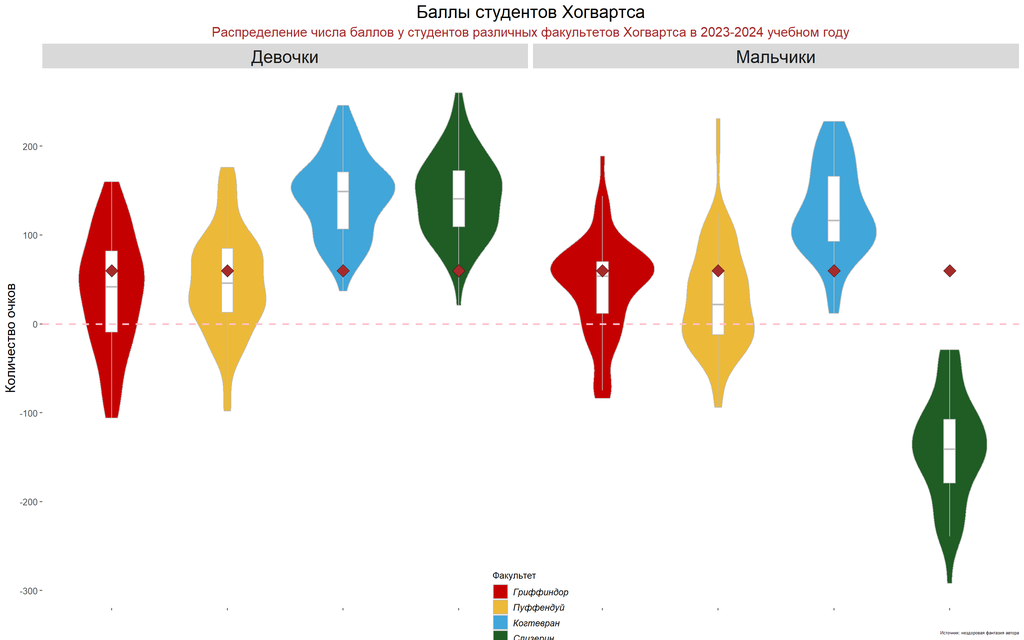

```r
hg <- summarise(group_by(hogwarts, house), MN=mean(result))

hogwarts |>
  ggplot() +
  geom_violin(aes(x = house,
                 y = result,
                 fill = house),
              color = "grey")+
  facet_grid(~ sex,
             labeller = as_labeller(c("female"="Девочки", "male" = "Мальчики")))+
  geom_boxplot(aes(x = house,
                 y = result),
               width = 0.1,
               outliers = FALSE,
               color = "grey")+
  theme_custom+
  scale_fill_manual(values = c("Gryffindor" = "#C50000",
                             "Hufflepuff" = "#ECB939",
                             "Ravenclaw" = "#41A6D9",
                             "Slytherin" = "#1F5D25"),
                    labels = c("Gryffindor" = "Гриффиндор",
                             "Hufflepuff" = "Пуффендуй",
                             "Ravenclaw" = "Когтевран",
                             "Slytherin" = "Слизерин"))+
  #scale_x_continuous(labels = NULL)+
  labs(title = "Баллы студентов Хогвартса",
       subtitle = "Распределение числа баллов у студентов различных факультетов Хогвартса в 2023-2024 учебном году",
       caption = "Источник: нездоровая фантазия автора",
       x = "",
       y = "Количество очков",
       fill = "Факультет")+
  geom_hline(yintercept = 0,
             linetype = "dashed",
             colour = "pink",
             size = 1)+
  geom_point(aes(x = house, y = mean(result)),
             shape = 23,
             color = "black",
             fill = "brown",
             size = 5)+
  scale_x_discrete(labels = NULL)+
  theme(
    plot.title = element_text(size = 20, hjust = 0.5),
    plot.caption = element_text(size = 5),
    plot.subtitle = element_text(size = 15, hjust = 0.5, color = "brown"),
    strip.text = element_text(size = 20),
    axis.text = element_text(size = 10),
    axis.title = element_text(size = 15),
    legend.title = element_text(size = 10),
    legend.text = element_text(size = 10, face = "italic"),
    legend.position = "inside",
    legend.position.inside = c(0.5, 0))
```